# 2212064

MA335 Lab Test

```r
#1(a)
setwd("m:/pc/downloads")
#1(b)
test <- read.csv("Real estate.csv",header=T)
attach(test)
head(test)
```

```
##   price     date  age MRT.station stores latitude longitude properties
## 1  37.9 2012.917 32.0    84.87882     10 24.98298  121.5402          1
## 2  42.2 2012.917 19.5   306.59470      9 24.98034  121.5395          1
## 3  47.3 2013.583 13.3   561.98450      5 24.98746  121.5439          1
## 4  54.8 2013.500 13.3   561.98450      5 24.98746  121.5419          3
## 5  43.1 2012.833  5.0   390.56840      5 24.97937  121.5425          1
## 6  32.1 2012.667  7.1  2175.03000      3 24.96305  121.5125          1
```

```r
#1(c)
price
```

```
##   [1] 37.9 42.2 47.3 54.8 43.1 32.1 40.3 46.7 18.8 22.1 41.4 58.1 39.3 23.8 34.3
##  [16] 50.5 70.1 37.4 42.3 47.7 29.3 51.6 24.6 47.9 38.8 27.0 56.2 33.6 47.0 57.1
##  [31] 22.1 25.0 34.2 49.3 55.1 27.3 22.9 25.3 47.7 46.2 15.9 18.2 34.7 34.1 53.9
##  [46] 38.3 42.0 61.5 13.4 13.2 44.2 20.7 27.0 38.9 51.7 13.7 41.9 53.5 22.6 42.4
##  [61] 21.3 63.2 27.7 55.0 25.3 44.3 50.7 56.8 36.2 42.0 59.0 40.8 36.3 20.0 54.4
##  [76] 29.5 36.8 25.6 29.8 26.5 40.3 36.8 48.1 17.7 43.7 50.8 27.0 18.3 48.0 25.3
##  [91] 45.4 43.2 21.8 16.1 41.0 51.8 59.5 34.6 51.0 62.2 38.2 32.9 54.4 45.7 30.5
## [106] 71.0 47.1 26.6 34.1 28.4 51.6 39.4 23.1  7.6 53.3 46.4 12.2 13.0 30.6 59.6
## [121] 31.3 48.0 32.5 45.5 57.4 48.6 62.9 55.0 60.7 41.0 37.5 30.7 37.5 39.5 42.2
## [136] 20.8 46.8 47.4 43.5 42.5 51.4 28.9 37.5 40.1 28.4 45.5 52.2 43.2 45.1 39.7
## [151] 48.5 44.7 28.9 40.9 20.7 15.6 18.3 35.6 39.4 37.4 57.8 39.6 11.6 55.5 55.2
## [166] 30.6 73.6 43.4 37.4 23.5 14.4 58.8 58.1 35.1 45.2 36.5 19.2 42.0 36.7 42.6
## [181] 15.5 55.9 23.6 18.8 21.8 21.5 25.7 22.0 44.3 20.5 42.3 37.8 42.7 49.3 29.3
## [196] 34.6 36.6 48.2 39.1 31.6
```

```r
summary(price)
```

```
##    Min. 1st Qu.  Median    Mean 3rd Qu.    Max.
##    7.60   27.60   39.40   38.40   47.75   73.60
```

```r
#1(d)
dim(test)
```

```
## [1] 200   8
```

```r
#2(a)
model1 <- lm(price~MRT.station)
summary(model1)
```

```
##
## Call:
## lm(formula = price ~ MRT.station)
##
## Residuals:
##     Min      1Q  Median      3Q     Max
## -36.077  -5.859  -0.902   5.853  29.193
##
## Coefficients:
##               Estimate Std. Error t value Pr(>|t|)
## (Intercept) 46.5375666  0.8712541   53.41   <2e-16 ***
## MRT.station -0.0072733  0.0005014  -14.51   <2e-16 ***
## ---
## Signif. codes:  0 '***' 0.001 '**' 0.01 '*' 0.05 '.' 0.1 ' ' 1
##
## Residual standard error: 9.431 on 198 degrees of freedom
## Multiple R-squared:  0.5152, Adjusted R-squared:  0.5128
## F-statistic: 210.4 on 1 and 198 DF,  p-value: < 2.2e-16
```

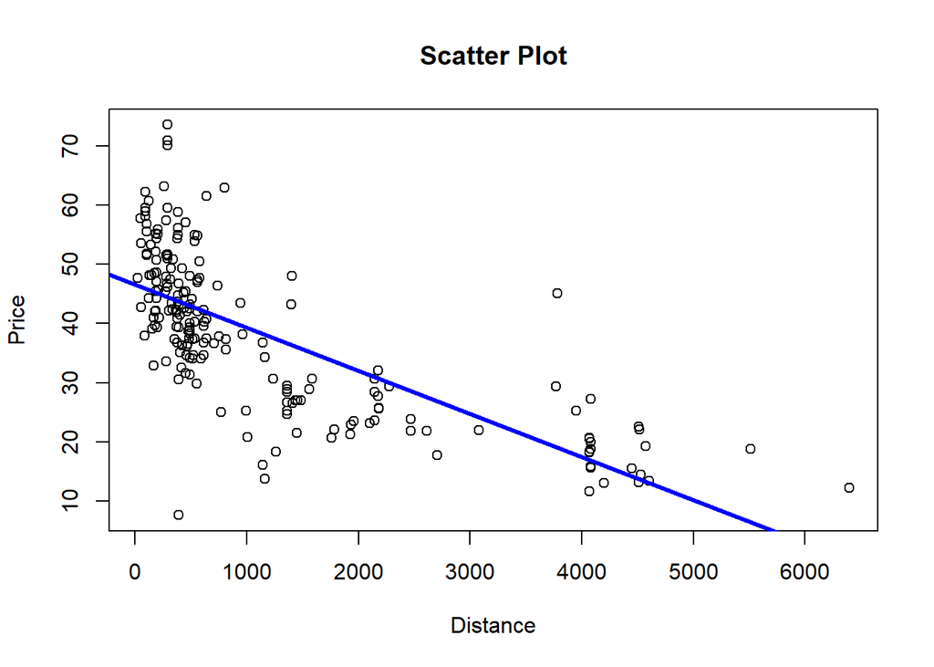

```r
#2(b)
plot(MRT.station,price, xlab = "Distance", ylab = "Price", main = "Scatter Plot")
abline(model1, lwd=3, col="blue")
```

## 3 From the below analysis, we see from the p-value which is smaller than < 2.2e − 16 that the null hypothesis is rejected, therefore we have evidence that model2 fits the data better. This is confirmed when we check the Adjusted R-squared which is 0.5128 for model1 and increases to 73.58% for model2. Also the Residual standard error from 9.431 for model1 reduces to 6.945 for model2. The F-statistics which decreases from 210.4 to 80.17 confirms the above conclusion, that model2 is better than model1.

```r
#3
model_2 <- lm(price~date+age+MRT.station+stores+latitude+longitude+properties, data=test)
model_2
```

```
##
## Call:
## lm(formula = price ~ date + age + MRT.station + stores + latitude +
##     longitude + properties, data = test)
##
## Coefficients:
## (Intercept)         date          age  MRT.station       stores     latitude
##  -8.244e+03    2.959e+00   -2.100e-01   -3.950e-03    8.048e-01    2.012e+02
##   longitude   properties
##  -2.227e+01    6.023e+00
```

```r
#3
summary(model_2)
```

```
##
## Call:
## lm(formula = price ~ date + age + MRT.station + stores + latitude +
##     longitude + properties, data = test)
##
## Residuals:
##     Min      1Q  Median      3Q     Max
## -35.570  -3.156  -0.146   3.295  25.192
##
## Coefficients:
##               Estimate Std. Error t value Pr(>|t|)
## (Intercept) -8.244e+03  1.066e+04  -0.773 0.440290
## date         2.959e+00  1.730e+00   1.710 0.088812 .
## age         -2.100e-01  4.568e-02  -4.597 7.76e-06 ***
## MRT.station -3.950e-03  9.940e-04  -3.973 0.000100 ***
## stores       8.048e-01  2.364e-01   3.404 0.000809 ***
## latitude     2.012e+02  5.023e+01   4.006 8.82e-05 ***
## longitude   -2.227e+01  8.438e+01  -0.264 0.792142
## properties   6.023e+00  7.079e-01   8.508 4.98e-15 ***
## ---
## Signif. codes:  0 '***' 0.001 '**' 0.01 '*' 0.05 '.' 0.1 ' ' 1
##
## Residual standard error: 6.945 on 192 degrees of freedom
## Multiple R-squared:  0.7451, Adjusted R-squared:  0.7358
## F-statistic: 80.17 on 7 and 192 DF,  p-value: < 2.2e-16
```

```r
#3
summary(model1)
```

```
##
## Call:
## lm(formula = price ~ MRT.station)
##
## Residuals:
##     Min      1Q  Median      3Q     Max
## -36.077  -5.859  -0.902   5.853  29.193
##
## Coefficients:
##               Estimate Std. Error t value Pr(>|t|)
## (Intercept) 46.5375666  0.8712541   53.41   <2e-16 ***
## MRT.station -0.0072733  0.0005014  -14.51   <2e-16 ***
## ---
## Signif. codes:  0 '***' 0.001 '**' 0.01 '*' 0.05 '.' 0.1 ' ' 1
##
## Residual standard error: 9.431 on 198 degrees of freedom
## Multiple R-squared:  0.5152, Adjusted R-squared:  0.5128
## F-statistic: 210.4 on 1 and 198 DF,  p-value: < 2.2e-16
```

```r
#3
anova(model1, model_2)
```

```
## Analysis of Variance Table
##
## Model 1: price ~ MRT.station
## Model 2: price ~ date + age + MRT.station + stores + latitude + longitude +
##     properties
##   Res.Df     RSS Df Sum of Sq      F    Pr(>F)
## 1    198 17611.2
## 2    192  9260.3  6    8350.9 28.857 < 2.2e-16 ***
## ---
## Signif. codes:  0 '***' 0.001 '**' 0.01 '*' 0.05 '.' 0.1 ' ' 1
```

##4

Below is the correlation between various columns

```r
#4

cor(test)
```

```
##                   price          date           age MRT.station       stores
## price        1.00000000  0.0604975769 -0.2872119593 -0.71777793  0.610455087
## date         0.06049758  1.0000000000  0.0002444424  0.07024104 -0.006477008
## age         -0.28721196  0.0002444424  1.0000000000  0.05886413  0.014621421
## MRT.station -0.71777793  0.0702410444  0.0588641325  1.00000000 -0.664151558
## stores       0.61045509 -0.0064770082  0.0146214213 -0.66415156  1.000000000
## latitude     0.58871322  0.0122400117  0.0234879937 -0.64892424  0.499150439
## longitude    0.66039569 -0.0364854554 -0.1091813395 -0.90993452  0.623025488
## properties   0.60196086  0.0657462407 -0.2774521738 -0.30237579  0.296172884
##                latitude   longitude  properties
## price        0.58871322  0.66039569  0.60196086
## date         0.01224001 -0.03648546  0.06574624
## age          0.02348799 -0.10918134 -0.27745217
## MRT.station -0.64892424 -0.90993452 -0.30237579
## stores       0.49915044  0.62302549  0.29617288
## latitude     1.00000000  0.58587149  0.21380001
## longitude    0.58587149  1.00000000  0.26757864
## properties   0.21380001  0.26757864  1.00000000
```

```r
#5

aov(price~as.factor(price))
```

```
## Call:
##    aov(formula = price ~ as.factor(price))
##
## Terms:
##                 as.factor(price) Residuals
## Sum of Squares          36327.19      0.00
## Deg. of Freedom              162        37
##
## Residual standard error: 1.497209e-13
## Estimated effects may be unbalanced
```